# French Doctoral Dissertation Field Classification: Bayesian and Discriminant Analysis

YICHEN_LI

# 1.Introduction

The data used in this project comes from the Kaggle platform and includes a dataset of semantic similarity for French doctoral thesis abstracts. This data is primarily in text form and aims to study the semantic features and affiliated domains of the abstracts. Each data record corresponds to an abstract of a doctoral thesis and is labeled with the category of the research field. The characteristics of the data include its high semantic complexity, diversity of research fields, and the potential presence of class imbalance, such as a significantly higher number of papers in certain fields compared to others.

# 2. Methods

## 2.1 Load the necessary libraries and data

```r
required_packages <- c("tidyverse", "data.table", "tm", "MASS", "e1071", "caret", "RcppCNPy", "ggplot2", "pheatmap","topicmodels","caret")

missing_packages <- required_packages[!(required_packages %in% installed.packages()[, "Package"])]
if (length(missing_packages) > 0) {
  install.packages(missing_packages, dependencies = TRUE)
}

suppressMessages({
  invisible(lapply(required_packages, library, character.only = TRUE))
})

# Load the paper metadata
metadata <- fread("/Users/lyly/R_project_DSIA_YICHEN_LI/mprojet_datas/mprojet3_data/french_thesis_20231021_metadata.csv")

# Loading embedding vectors (.npy format)
embeddings <- npyLoad("/Users/lyly/R_project_DSIA_YICHEN_LI/mprojet_datas/mprojet3_data/french_thesis_20231021_embeddings.npy")

# Load the list of training set papers
training_list <- readLines("/Users/lyly/R_project_DSIA_YICHEN_LI/mprojet_datas/mprojet3_data/training_list_2000.txt")
```

```r
# View the column name of the metadata
cat("The name of the column for the metadata:\n")
```

```
## The name of the column for the metadata:
```

```r
print(colnames(metadata))
```

```
## [1] "URL"         "Title"       "Author"      "Description" "Direction"
## [6] "Domain"      "Statuts"     "Date"
```

## 2.2 Data preprocessing

Clean up text data, remove stop words, punctuation.

```r
# Text cleanup function
clean_text <- function(text) {
  text <- tolower(text)                    # Lowercase
  text <- removePunctuation(text)          # Remove punctuation
  text <- removeNumbers(text)              # Remove numbers
  text <- removeWords(text, stopwords("fr")) # Remove French stop words
  text <- stripWhitespace(text)            # Remove extra spaces
  return(text)
}

# Clean up the "Short description" column
metadata$cleaned_description <- sapply(metadata$`Short description`, clean_text)
```

## 2.3 Feature extraction

The features corresponding to the training data are extracted from the embedding matrix first, and the corresponding metadata is extracted to generate the target variable (research field label)

1. Convert the training data list training_list into a numeric index that is used to extract the corresponding features from the embedding matrix.
2. Extract the labels corresponding to the training set from the metadata, and make sure that the labels are of factor type so that they can be applied to the classification model.

```r
# Convert training_list to numeric
training_list_numeric <- as.numeric(training_list)

# Extract embedding features
features <- embeddings[training_list_numeric, ]
cat("Feature dimensions: ", dim(features), "\n")
```

```
## Feature dimensions:  2000 768
```

```r
# Extract the target variable corresponding to the metadata
metadata_train <- metadata[training_list_numeric, ]
labels <- metadata_train$Domain
cat("Number of target variables: ", length(labels), "\n")
```

```
## Number of target variables:  2000
```

```r
# Make sure labels is of the factor type
if (!is.factor(labels)) {
  labels <- as.factor(labels)
  cat("Labels have been converted to a factor type\n")
}
```

```
## Labels have been converted to a factor type
```

The features of 2000 samples were extracted from the embedding matrix, each sample contained 768 feature dimensions, and 2000 target variables were extracted from the metadata and converted into factor types.

## 2.4 Dimensionality reduction

Some features may have constant values (with a standard deviation of 0) that do not provide any useful information in the classification task and therefore need to be removed from the dataset. Linear Discriminant Analysis (LDA) was used to reduce the dimensionality of features.

1. Identify constant features by calculating the standard deviation of each feature and remove them from the feature matrix.
2. Linear Discriminant Analysis (LDA) is used to reduce dimensionality, and high-dimensional features are projected into low-dimensional space, while retaining the discrimination information between categories.

```r
# Removes the constant feature
feature_sd <- apply(features, 2, function(x) sd(x))
constant_features <- which(feature_sd == 0)
if (length(constant_features) > 0) {
  cat("Number of constant features: ", length(constant_features), "\n")
  features <- features[, -constant_features]
}
```

```
## Number of constant features:  4
```

```r
cat("Feature dimensions after removing a constant feature: ", dim(features), "\n")
```

```
## Feature dimensions after removing a constant feature:  2000 764
```

```r
# Perform LDA
lda_model <- lda(features, grouping = labels)

# Extract features after dimensionality reduction
features_lda <- predict(lda_model)$x
colnames(features_lda) <- paste0("LD", 1:ncol(features_lda))
cat("Dimensionality reduction is completed, and the feature dimension is as follows: ", dim(features_lda), "\n")
```

```
## Dimensionality reduction is completed, and the feature dimension is as follows:  2000 764
```

Four constant features were successfully detected and removed, and although the number of features after dimensionality reduction did not decrease, the data may have been linearly transformed by the LDA method, providing more discriminating features for the classification task.

## 2.5 Bayesian classification

The Naïve Bayes model was used to classify the reduced data. The Naive Bayes model is a simple and efficient probability-based classification method, which is especially suitable for the classification task of processing text or high-dimensional data. In this step, the dimensionality reduction feature data is randomly divided into a training set and a test set at a ratio of 8:2, and the naïve Bayes model is trained using the training set. Subsequently, the test set was used to make predictions, and the classification effect of the model was evaluated by the confusion matrix

```r
# Divide the training set and the test set
set.seed(123)
train_index <- sample(seq_len(nrow(features_lda)), size = 0.8 * nrow(features_lda))
train_data <- features_lda[train_index, ]
train_labels <- labels[train_index]
test_data <- features_lda[-train_index, ]
test_labels <- labels[-train_index]

# Train a naïve Bayesian model
nb_model <- naiveBayes(train_data, train_labels)

# Test set prediction
predictions <- predict(nb_model, test_data)

# Calculate the confusion matrix for the initial model
cm_1 <- confusionMatrix(predictions, test_labels)
```

## 2.6 Model optimization

First, the number of samples for each category is counted, and rare categories are identified, and then these categories are combined into “Other”. In order to maintain the consistency of the categorical distribution, the hierarchical sampling (createDataPartition) method was used to repartition the training and test sets. Subsequently, the naïve Bayes classification model was retrained on the new label data and predicted on the test set. By comparing the confusion matrices (cm_1 and cm_2 before and after optimization, can evaluate the effectiveness of your optimization strategy.

```r
set.seed(123)

# Merge Rare Category as "Other"
# Define thresholds for rare categories (sample ≤ 10)
threshold <- 10

# Count the number of samples for each category
label_counts <- table(labels)

# Identify rare categories
rare_classes <- names(label_counts[label_counts <= threshold])

# Merge Rare Categories into "Other"
labels_modified <- as.character(labels)
labels_modified[labels_modified %in% rare_classes] <- "Other"
labels_modified <- factor(labels_modified)

# Use createDataPartition for hierarchical sampling to keep the distribution of categories consistent between the training and test sets
train_index <- createDataPartition(labels_modified, p = 0.8, list = FALSE)
train_data <- features_lda[train_index, ]
train_labels <- labels_modified[train_index]
test_data <- features_lda[-train_index, ]
test_labels <- labels_modified[-train_index]

# Train a naïve Bayesian model
nb_model <- naiveBayes(train_data, train_labels)

# Make predictions on the test set
predictions <- predict(nb_model, test_data)

cm_2 <- confusionMatrix(predictions, test_labels)
```

# 3. Results

## 3.1 Performance Evaluation

```r
# Extract performance metrics

# Initial model
accuracy_1 <- cm_1$overall["Accuracy"]

# Optimize the model
accuracy_2 <- cm_2$overall["Accuracy"]

print("Initial Model Performance Metrics:")
```

```
## [1] "Initial Model Performance Metrics:"
```

```r
print(paste("Accuracy:", round(accuracy_1, 4)))
```

```
## [1] "Accuracy: 0.3725"
```

```r
print("Optimize model performance metrics:")
```

```
## [1] "Optimize model performance metrics:"
```

```r
print(paste("Accuracy:", round(accuracy_2, 4)))
```

```
## [1] "Accuracy: 0.9383"
```

The initial model performed poorly with an accuracy of 37.25%, mainly because the Bayesian model is sensitive to category distributions, and there are rare classes with very few samples in the dataset. When the Bayesian classifier calculates the conditional probability of the category, the insufficient sample of the rare category will lead to the instability of the probability estimation, which will affect the overall classification performance. In addition, the existence of rare classes may cause the model to overfit these classes in the optimization process, while ignoring the feature learning of the main classes, which ultimately reduces the generalization ability of the model.

## 3.2 Analysis of important characteristics of LDA

Linear Discriminant Analysis (LDA) is a supervised learning technique for dimensionality reduction, the goal of which is to map high-dimensional data to lower-dimensional discriminant spaces by maximizing separability between classes and minimizing variance within classes. In LDA, the contribution of each Discriminant Axis to classification is determined by the weight values in the feature scaling matrix, and the magnitude of the weight values reflects the importance of each feature to the corresponding discriminant axis.

The weight matrix of the LDA model was extracted, and the top 5 most important features on each discriminant axis were identified. In addition, we counted the frequency of these important features in all discriminant axes, and finally generated a data frame containing the names of features and their importance counts in order to rank and analyze the importance of features.

```r
# Extract the LDA weight matrix
lda_weights <- lda_model$scaling

# Get the top 5 features that are most important for each discriminant axis
top_n <- 5
top_features <- apply(lda_weights, 2, function(x) {
  important_features <- order(abs(x), decreasing = TRUE)[1:top_n]
  return(important_features)
})

# Convert to vectors and count frequencies
top_features_vector <- as.vector(top_features)
feature_counts <- table(top_features_vector)
sorted_feature_counts <- sort(feature_counts, decreasing = TRUE)

# Converts the feature number to a numeric type
top_features_named <- as.numeric(names(sorted_feature_counts))
feature_names <- colnames(features)

if (is.null(feature_names) || any(feature_names == ""))
  feature_names <- paste0("Feature", 1:ncol(features))
  colnames(features) <- feature_names

# Check if the feature number is out of range
max_feature_id <- length(feature_names)

# Map the feature number to the name, and those that are out of range will get NA
feature_names_selected <- feature_names[top_features_named]
na_indices <- which(is.na(feature_names_selected))

# Create a data frame that contains the feature name and count
feature_importance_df <- data.frame(
  Feature_ID = top_features_named,
  Feature_Name = feature_names_selected,
  Count = as.numeric(sorted_feature_counts)
)

# Check out the top 10 most important features
print(head(feature_importance_df, 10))
```

```
##    Feature_ID Feature_Name Count
## 1         461   Feature461   320
## 2         692   Feature692   113
## 3         567   Feature567    91
## 4         382   Feature382    87
## 5         642   Feature642    79
## 6          50    Feature50    48
## 7          73    Feature73    47
## 8         608   Feature608    28
## 9         542   Feature542    27
## 10        641   Feature641    25
```

As can be seen from the table, Feature461 is the most important feature in the LDA model, and it is selected as the top 5 important features in the discriminant axis up to 320 times, significantly more than the other features. This indicates that Feature461 plays a central role in category discrimination and is the feature that contributes the most to the discriminant power of the model. Other features, such as Feature692 and Feature567, were selected 113 and 91 times, respectively, indicating that they also have a high discriminative ability in the model, but their importance is significantly weaker than that of Feature461. Lower-ranking features, such as Feature641, may still have some class discrimination on some discriminant axes, although less frequent.

This result shows that the important features of the LDA model have the characteristics of concentration and long-tail distribution: a few features contribute more to the discriminant power of the model, while most of the features have a low importance.

## 3.3 visualization

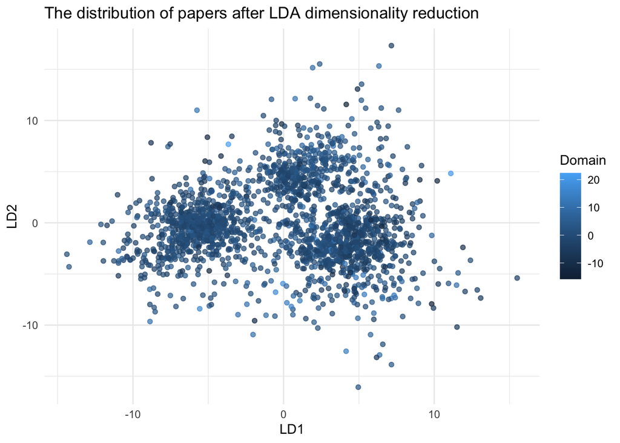

```r
# Distribution of papers after dimensionality reduction
lda_df <- data.frame(features_lda, labels)
colnames(lda_df) <- c("Dim1", "Dim2", "Domain")

# Draw a scatter plot of the reduced dimensionality distribution
ggplot(lda_df, aes(x = Dim1, y = Dim2, color = Domain)) +
  geom_point(alpha = 0.7) +
  theme_minimal() +
  labs(
    title = "The distribution of papers after LDA dimensionality reduction",
    x = "LD1",
    y = "LD2"
  )
```

# 4.Conclusion

Through the processing, dimensionality reduction and classification analysis of abstract data of French doctoral dissertation, a text classification method based on Bayesian classifier and linear discriminant analysis (LDA) was explored. In the data preprocessing, the constant features were identified and removed, and the high-dimensional data was successfully projected into the low-dimensional discriminant space by using LDA, which preliminarily revealed the category distribution characteristics of the data. By analyzing the LDA weight matrix, the features that contribute the most to the category discrimination are further identified, which provides a strong basis for the subsequent model optimization and feature selection.

In classification modeling, the initial model performed poorly (only 37.25% accuracy), mainly due to the uneven distribution of categories and the presence of rare classes. By merging the rare categories into “Other” and re-stratifying the dataset, the accuracy of the optimized model was greatly improved to 93.83%, indicating that the balance of data distribution is crucial to the improvement of Bayesian classifier performance. Although LDA performs well in dimensionality reduction, there is still some overlap in the categories in the low-dimensional space, reflecting the semantic complexity of text data and the limitations of linear methods.

This experiment verifies the effectiveness of Bayesian classifiers and LDA methods in text classification tasks, but also reveals the direction of further improvement, such as the introduction of nonlinear dimensionality reduction techniques (such as t-SNE or UMAP) and more complex classification models (such as random forests or deep learning) to better capture the category discrimination information in complex data.